# Ch 6: Overfitting, Regularization, and Information Criteria

- **Overfitting** and **underfitting**
- **Regularizing prior** and **information criteria**

## The problem with parameters

Consider the shape of the rlationship between body mass and brain volume.

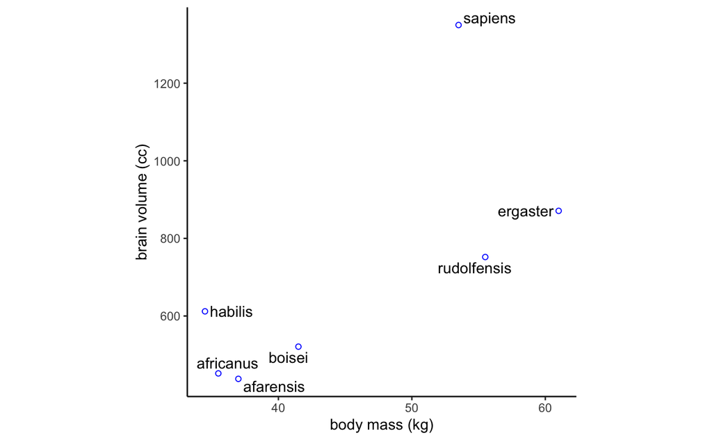

```r
library(ggrepel)
library(tidyverse)
d <- tibble(
  species = c("afarensis", "africanus", "habilis", "boisei", "rudolfensis",
                "ergaster", "sapiens"),
  brain = c(438, 452, 612, 521, 752, 871, 1350),
  mass = c(37.0, 35.5, 34.5, 41.5, 55.5, 61.0, 53.5)
)

ggplot(d, aes(mass, brain)) +
  geom_point(shape = 21, color = "blue") +
  geom_text_repel(aes(label = species)) +
  scale_x_continuous("body mass (kg)", breaks = 10 * (3:7)) +
  scale_y_continuous("brain volume (cc)", breaks = 200 * (3:6)) +
  theme_classic() +
  theme(aspect.ratio = 1)
```

What shape should we choose? First, try a linear one:

$$v_i \sim \mathcal{N}(\mu_i, \sigma) \\
\mu_i = \alpha + \beta_1 m_i$$

```r
m6.1 <- lm(brain ~ mass, data = d)
1 - var(resid(m6.1)) / var(d$brain)
```

```
[1] 0.490158
```

```r
summary(m6.1)
```

```
Call:
lm(formula = brain ~ mass, data = d)

Residuals:
      1       2       3       4       5       6       7
 -99.86  -54.83  125.86 -109.96 -168.60 -163.39  470.77

Coefficients:
            Estimate Std. Error t value Pr(>|t|)
(Intercept) -227.629    439.794  -0.518   0.6268
mass          20.689      9.436   2.192   0.0798 .
---
Signif. codes:  0 ‘***’ 0.001 ‘**’ 0.01 ‘*’ 0.05 ‘.’ 0.1 ‘ ’ 1

Residual standard error: 252.1 on 5 degrees of freedom
Multiple R-squared:  0.4902,    Adjusted R-squared:  0.3882
F-statistic: 4.807 on 1 and 5 DF,  p-value: 0.07985
```

With more complicated polynomials, “model fit” (i.e. $R^2$) increases but model loses meaning.

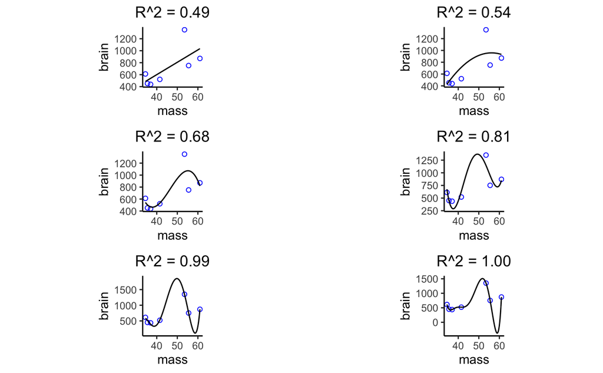

```r
library(cowplot)
m6.2 <- lm(brain ~ mass + I(mass^2), data = d)
m6.3 <- lm(brain ~ mass + I(mass^2) + I(mass^3), data = d)
m6.4 <- lm(brain ~ mass + I(mass^2) + I(mass^3) + I(mass^4), data = d)
m6.5 <- lm(brain ~ mass + I(mass^2) + I(mass^3) + I(mass^4) + I(mass^5),
           data = d)
m6.6 <- lm(brain ~ mass + I(mass^2) + I(mass^3) + I(mass^4) + I(mass^5) +
             I(mass^6),
           data = d)

plot_model <- function(m) {
  r2 <- 1 - var(resid(m)) / var(d$brain)
  ggplot(m$model, aes(mass, brain)) +
    geom_point(shape = 21, color = "blue") +
    stat_function(fun = ~ predict(m, newdata = data.frame(mass = .x))) +
    labs(title = sprintf("R^2 = %0.2f", r2)) +
    theme_classic() +
    theme(aspect.ratio = 1,
          plot.title = element_text(hjust = 0.5))
}
list(m6.1, m6.2, m6.3, m6.4, m6.5, m6.6) %>%
  purrr::map(plot_model) %>%
  plot_grid(plotlist = ., ncol = 2)
```

Conversely, too *few* parameters leads to poor predictions as well.

$$v_i \sim \mathcal{N}(\mu, \sigma) \\
\mu = \alpha$$

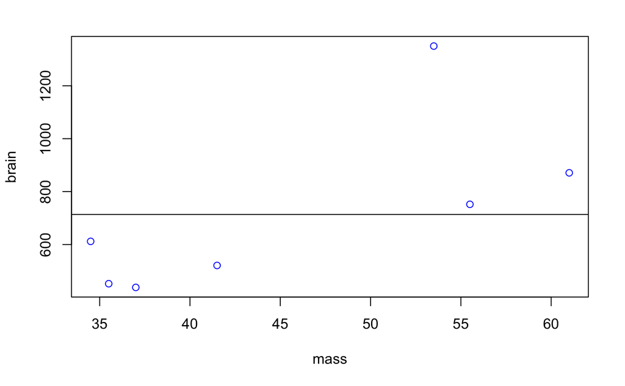

```r
m6.7 <- lm(brain ~ 1, data = d)
pred_int <- predict(m6.7,
                    newdata = data.frame(mass = 50),
                    interval = "predict")[1, 2:3]
plot(brain ~ mass, d, pch = 21, col = "blue")
abline(m6.7)
```

There is a trade-off between sensitivity and complexity. Complex models change dramatically when removing data points, simple models less so.

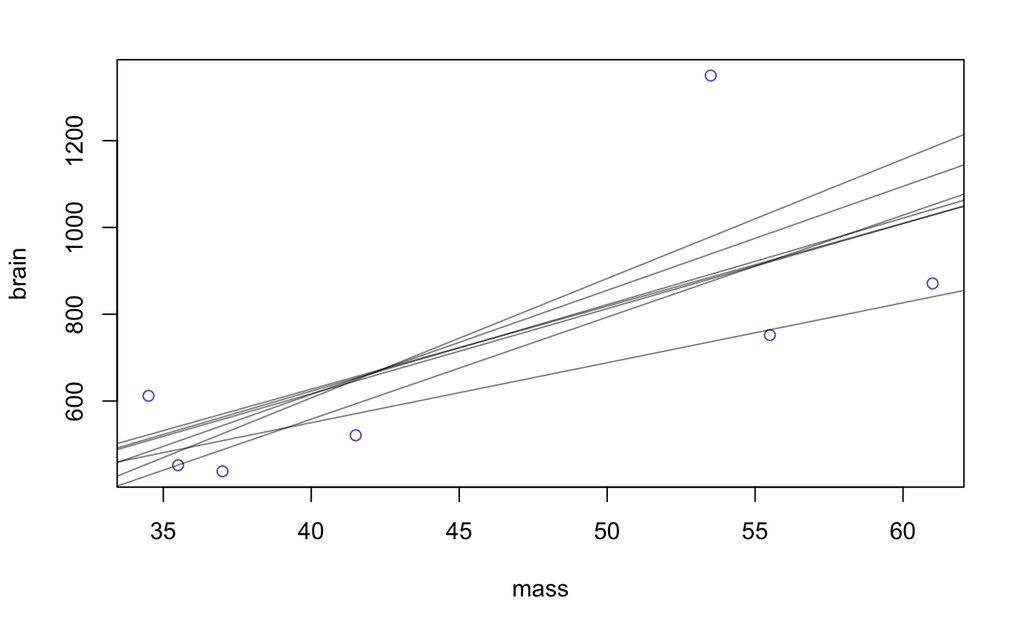

```r
library(rethinking)
plot(brain ~ mass, d, col = "slateblue")
for (i in 1:nrow(d)) {
  d.new <- d[-i, ]
  m0 <- lm(brain ~ mass, d.new)
  abline(m0, col = col.alpha("black", 0.5))
}
```

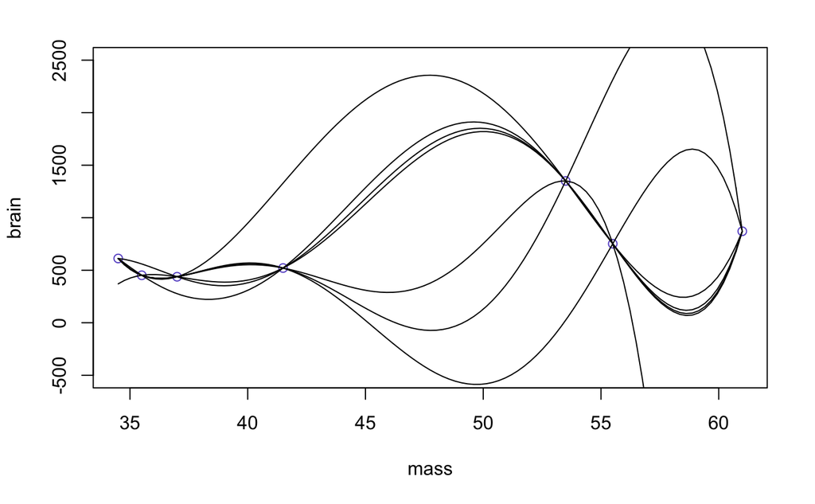

```r
plot(brain ~ mass, d, col = "slateblue", ylim = c(-500, 2500))
for (i in 1:nrow(d)) {
  d.new <- d[-i, ]
  m0 <- lm(brain ~ mass + I(mass^2) + I(mass^3) + I(mass^4) + I(mass^5) +
             I(mass^6),
           data = d.new)
  f <- function(x) suppressWarnings(predict(m0, newdata = data.frame(mass = x)))
  curve(f, add = TRUE)
}
```

## Information theory and model performance

**Information entropy** is the uncertainty contained in a probability distribution.

$$H(p) = -E~log(p_i) = -\sum_{i=1}^n p_i ~ log(p_i)$$

**Divergence** is the additional uncertainty induced by using probabilities from one distribution to describe another distribution.

$$D_{KL}(p,q) = \sum_i p_i(log(p_i) - log(q_i)) = \sum_i p_i ~ log \left( \frac{p_i}{q_i} \right)$$

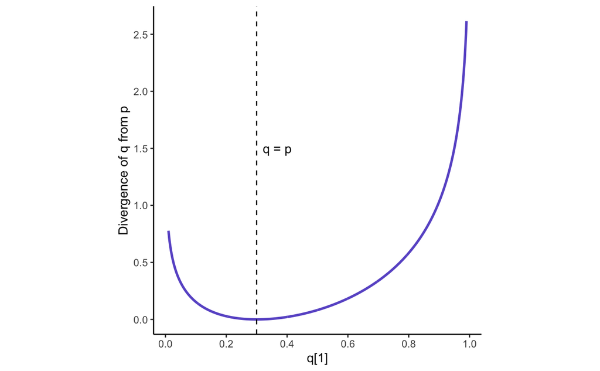

```r
library(tidyverse)
p <- 0.3 #, 0.7
q <- seq(0.01, 0.99, length.out = 1000)
divergence <- function(p, q) {
  sum(p * log(p / q))
}
tibble(
  p,
  q,
  d = map2_dbl(p, q, ~ divergence(c(.x, 1 - .x), c(.y, 1 - .y)))
) %>%
  ggplot(aes(q, d)) +
  geom_line(color = "slateblue", size = 1) +
  geom_vline(xintercept = p, linetype = "dashed") +
  annotate("text", p + 0.02, 1.5, label = "q = p", hjust = 0) +
  scale_x_continuous("q[1]", breaks = seq(0, 1, by = 0.2)) +
  scale_y_continuous("Divergence of q from p",
                     breaks = seq(0, 2.5, by = 0.5)) +
  theme_classic() +
  theme(aspect.ratio = 1)
```

**Deviance** is a measure a *relative* model fit and an approximation of K-L divergence (since we don’t know the true $p$).

$$D(q) = -2 \sum_i log(q_i)$$

where $q_i$ is the likelihood of case $i$. This can be calculated for a linear model using `dnorm()`.

```r
# fit model with lm
m6.1 <- lm(brain ~ mass, d)

# compute deviance
-2 * logLik(m6.1)
```

```
'log Lik.' 94.92499 (df=3)
```

How to compute $D$:

```r
# standardize the mass before fitting
d$mass.s <- (d$mass - mean(d$mass)) / sd(d$mass)
m6.8 <- rethinking::map(
  alist(
    brain ~ dnorm(mu, sigma),
    mu <- a + b * mass.s
  ),
  data = d,
  start = list(a = mean(d$brain), b = 0, sigma = sd(d$brain)),
  method = "Nelder-Mead"
)

# extract MAP estimates
theta <- coef(m6.8)

# compute deviance
dev <- -2 * sum(dnorm(d$brain,
                      mean = theta[1] + theta[2] * d$mass.s,
                      sd = theta[3],
                      log = TRUE))
dev
```

```
[1] 94.92499
```

In the code above, the likelihood of each point given the model is given by `dnorm()`. The mean is a linear function of the predictor `d$mass.s` by definition and the standard deviation is constant. `log = TRUE` returns the log likelihood, which we sum and multiply by -2.

### From deviance to out-of-sample

Training and test samples, essentially k-fold validation.

```r
N <- 20
kseq <- 1:5
dev <- sapply(kseq, function(k) {
  print(k)
  r <- mcreplicate(1e4, sim.train.test(N = N, k = k), mc.cores = 4)
  c(mean(r[1, ]), mean(r[2, ]), sd(r[1, ]), sd(r[2, ]))
})
```

```
[1] 1

[1] 2

[1] 3

[1] 4

[1] 5
```

```r
plot(kseq, dev[1, ],
     ylim = c(min(dev[1:2, ]) - 5, max(dev[1:2, ]) + 10),
     xlim = c(1, 5.1),
     xlab = "Number of parameters",
     ylab = "deviance",
     pch = 16,
     col = rangi2)
mtext(concat("N = ", N))
```

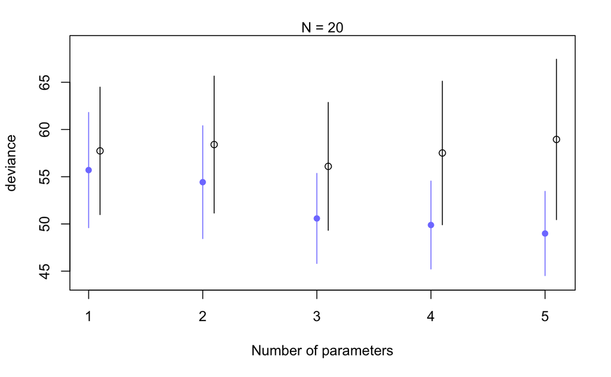

```r
points(kseq + 0.1, dev[2, ])
for (i in kseq) {
  pts_in <- dev[1, i] + c(-1, +1) * dev[3, i]
  pts_out <- dev[2, i] + c(-1, +1) * dev[4, i]
  lines(c(i, i), pts_in, col = rangi2)
  lines(c(i, i) + 0.1, pts_out)
}
```

## Information criteria

### Akaike IC

$$AIC = D_{train} + 2p$$

Assumes flat prior, Gaussian posterior, $N$ >> $k$

### Deviance IC

$$DIC = \bar{D} + (\bar{D} - \hat{D}) = \bar{D} + p_D$$

Where $D$ is the posterior distribution of deviance, $\bar{D}$ is the average of $D$, and $\hat{D}$ is the deviance calculated at the posterior mean. With flat priors, $DIC$ reduces to $AIC$. But regularizing priors constrain model flexibility to $p_D$ can be less than 2 times the number of parameters.

### Widely Applicable IC

A *pointwise* IC. There are two parts. Let $Pr(y_i)$ be the average likelihood of observation $i$ in the training sample. Then the first part, the log-pointwise-predictive-density (lppd), is:

$$lppd = \sum_{i=1}^N log ~ Pr(y_i)$$

This is the pointwise analog of deviance, averaged over the posterior distribution. The next part is the effective number of parameters $p_{WAIC}$. Let $V(y_i)$ be the variance in log-likelihood of observation $i$ in the training sample.

$$p_{WAIC} = \sum_{i=1}^N V(y_i)$$

Then WAIC is defined as:

$$WAIC = -2(lppd - p_{WAIC})$$

## Using information criteria

Both **model comparison** and **model averaging**.

### Model comparison

```r
# load data
data("milk")
d <- drop_na(milk) %>%
  mutate(neocortex = neocortex.perc / 100)

# fit four models
a.start <- mean(d$kcal.per.g)
sigma.start <- log(sd(d$kcal.per.g))
m6.11 <- rethinking::map(
  alist(
    kcal.per.g ~ dnorm(a, exp(log.sigma))
  ),
  data = d,
  start = list(a = a.start, log.sigma = sigma.start)
)
m6.12 <- rethinking::map(
  alist(
    kcal.per.g ~ dnorm(mu, exp(log.sigma)),
    mu <- a + bn * neocortex
  ),
  data = d,
  start = list(a = a.start, bn = 0, log.sigma = sigma.start)
)
m6.13 <- rethinking::map(
  alist(
    kcal.per.g ~ dnorm(mu, exp(log.sigma)),
    mu <- a + bm * log(mass)
  ),
  data = d,
  start = list(a = a.start, bm = 0, log.sigma = sigma.start)
)
m6.14 <- rethinking::map(
  alist(
    kcal.per.g ~ dnorm(mu, exp(log.sigma)),
    mu <- a + bn * neocortex + bm * log(mass)
  ),
  data = d,
  start = list(a = a.start, bn = 0, bm = 0, log.sigma = sigma.start)
)
```

```r
# Using rethinking
( milk.models <- compare(m6.11, m6.12, m6.13, m6.14) )
```

|  | WAIC | SE | dWAIC | dSE | pWAIC | weight |
| --- | --- | --- | --- | --- | --- | --- |
| m6.14 | -15.0 | 7.81 | 0.0 | NA | 4.9 | 0.92 |
| m6.13 | -8.3 | 5.59 | 6.7 | 5.38 | 2.8 | 0.03 |
| m6.11 | -8.0 | 4.61 | 6.9 | 7.38 | 1.9 | 0.03 |
| m6.12 | -6.6 | 4.18 | 8.4 | 7.69 | 2.7 | 0.01 |

```r
# Using tidyverse
mod.list <- list(m6.11 = m6.11, m6.12 = m6.12, m6.13 = m6.13, m6.14 = m6.14)
akaike_weight <- function(aic) {
  daic <- aic - min(aic)
  exp(-1/2 * daic) / sum(exp(-1/2 * daic))
}
map_dfr(mod.list, WAIC, .id = "model") %>%
  rename(pWAIC = penalty, SE = std_err) %>%
  arrange(WAIC) %>%
  transmute(model, WAIC, pWAIC,
            dWAIC = WAIC - min(WAIC),
            weight = akaike_weight(WAIC),
            SE)
```

| model | WAIC | pWAIC | dWAIC | weight | SE |
| --- | --- | --- | --- | --- | --- |
| m6.14 | -15.375895 | 4.632049 | 0.000000 | 0.93887429 | 7.589393 |
| m6.11 | -8.124997 | 1.908260 | 7.250898 | 0.02500893 | 4.581089 |
| m6.13 | -8.066721 | 2.948845 | 7.309173 | 0.02429073 | 5.593911 |
| m6.12 | -6.627142 | 2.740287 | 8.748753 | 0.01182606 | 4.366282 |

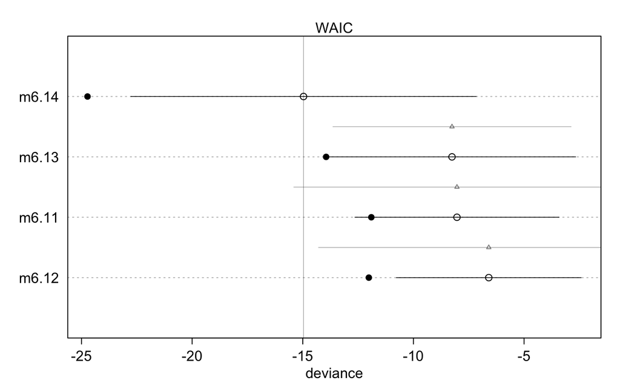

```r
plot(milk.models, SE = TRUE, dSE = TRUE)
```

Comparing posterior densities of parameters for the four models fit to the primate milk data

```r
coeftab(m6.11, m6.12, m6.13, m6.14)
```

```
          m6.11   m6.12   m6.13   m6.14
a            0.66    0.35    0.71   -1.09
log.sigma   -1.79   -1.80   -1.85   -2.16
bn             NA    0.45      NA    2.79
bm             NA      NA   -0.03   -0.10
nobs           17      17      17      17
```

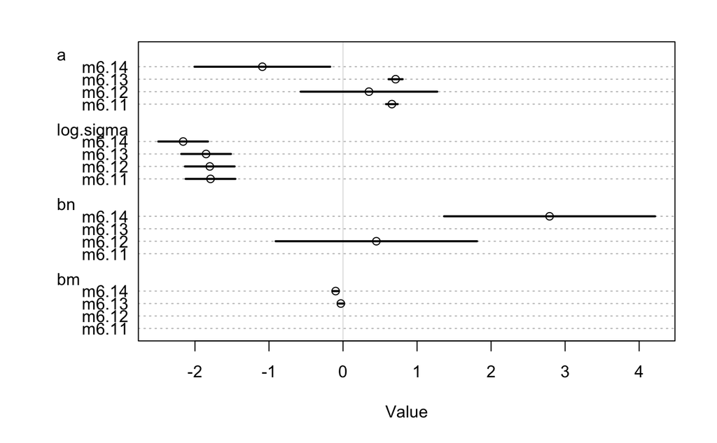

```r
plot(coeftab(m6.11, m6.12, m6.13, m6.14))
```

### Model averaging

Plot the best performing model

```r
# neocortex from 0.5 to 0.8
nc.seq <- seq(from = 0.5, to = 0.8, length.out = 30)
d.predict <- list(
  kcal.per.g = rep(0, 30), # empty outcome
  neocortex = nc.seq,      # sequence of neocortex
  mass = rep(4.5, 30)      # average mass
)

pred.m6.14 <- link(m6.14, data = d.predict)
mu <- apply(pred.m6.14, 2, mean)
mu.PI <- apply(pred.m6.14, 2, PI)

# Plot using base R
plot(kcal.per.g ~ neocortex, d, col = rangi2)
lines(nc.seq, mu, lty = 2)
```

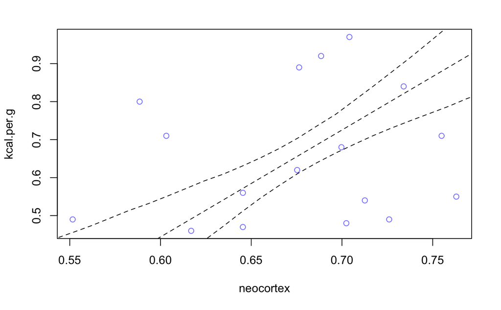

```r
lines(nc.seq, mu.PI[1, ], lty = 2)
lines(nc.seq, mu.PI[2, ], lty = 2)
```

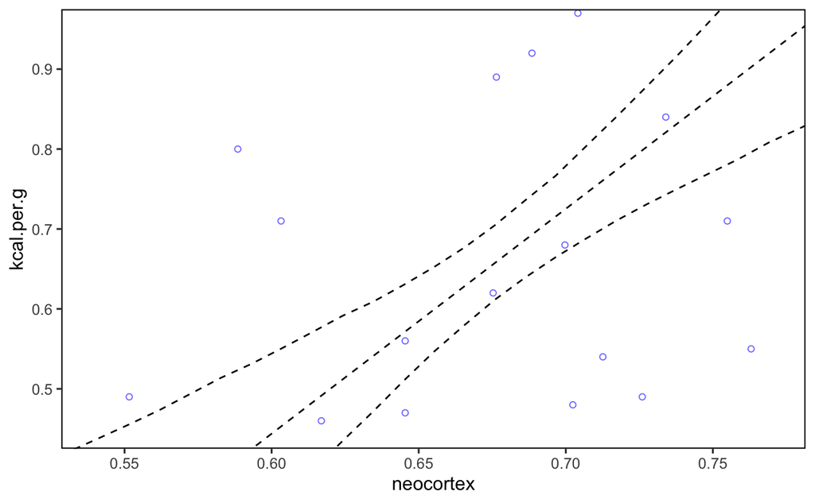

```r
# plot using ggplot
pred.data <- tibble(neocortex = nc.seq, mu, mu_lwr = mu.PI[1, ],
                    mu_upr = mu.PI[2, ])
ggplot(d, aes(neocortex, kcal.per.g)) +
  geom_point(shape = 21, col = rangi2) +
  geom_line(aes(y = mu), pred.data, linetype = 2) +
  geom_line(aes(y = mu_lwr), pred.data, linetype = 2) +
  geom_line(aes(y = mu_upr), pred.data, linetype = 2) +
  scale_x_continuous(breaks = seq(0.55, 0.75, by = 0.05)) +
  scale_y_continuous(breaks = seq(0.5, 0.9, by = 0.1)) +
  coord_cartesian(xlim = c(0.54, 0.77), ylim = c(0.45, 0.95)) +
  theme_classic(base_size = 12) +
  theme(axis.line = element_blank(),
        panel.border = element_rect(color = "black", fill = NA, size = 0.75))
```

Now overlay the averaged models

```r
plot(kcal.per.g ~ neocortex, d, col = rangi2)
lines(nc.seq, mu, lty = 2)
```

```r
lines(nc.seq, mu.PI[1, ], lty = 2)
lines(nc.seq, mu.PI[2, ], lty = 2)
```

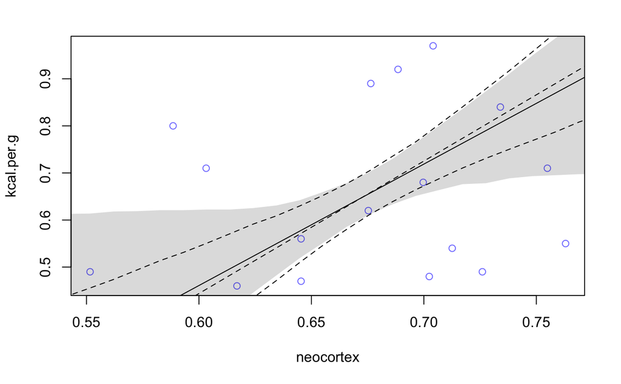

```r
milk.ensemble <- ensemble(m6.11, m6.12, m6.13, m6.14, data = d.predict)
mu <- apply(milk.ensemble$link, 2, mean)
mu.PI <- apply(milk.ensemble$link, 2, PI)
lines(nc.seq, mu)
shade(mu.PI, nc.seq)
```